# Tangents to Parabola

Aaron Ferrucci

October 1, 2018

$f(x) = x^2 + 1$

$g(x) = -x^2 - 2x - 1$

$f'(x) = 2x$

$g'(x) = -2x - 2$

$m = f'(x_1) = g'(x_2)$

$m = 2x_1 = -2x_2 - 2$

$x_2 = -x_1 - 1$

$m = \frac{f(x_1) - g(x_2)}{x_1 - x_2}$

$= \frac{x_1^2 + 1 - (-x_2 - 2x_2 - 1)}{x_1 - x_2}$

$= \frac{x_1^2 + 1 - (-(-x_1 - 1)^2 - 2(-x_1 - 1))}{x_1 - (-x_1 - 1)}$

$= \frac{x_1^2 + 1 - (-(x_1^2 +2x_1 + 1) + 2x_1 + 2)}{2x_1 + 1}$

$= \frac{x_1^2 + 1 - (-x_1^2 - 2x_1 - 1 + 2x_1 + 2)}{2x_1 + 1}$

$= \frac{x_1^2 + 1 + x_1^2 + 2x_1 + 1 - 2x_1 - 2}{2x_1 + 1}$

$= \frac{2x_1^2 +1}{2x_1 + 1} = 2x_1$

$\implies 2x_1^2 + 1 = 4x_1 + 2x_1$

$0 = 2x_1^2 + 2x_1 - 1$

$0 = x_1^2 + x_1 - \frac{1}{2}$

$x_1 = \frac{-1 \pm- \sqrt(3)}{2}$

$x_2 = -x_1 - 1 = \frac{-1 \mp \sqrt(3)}{2}$

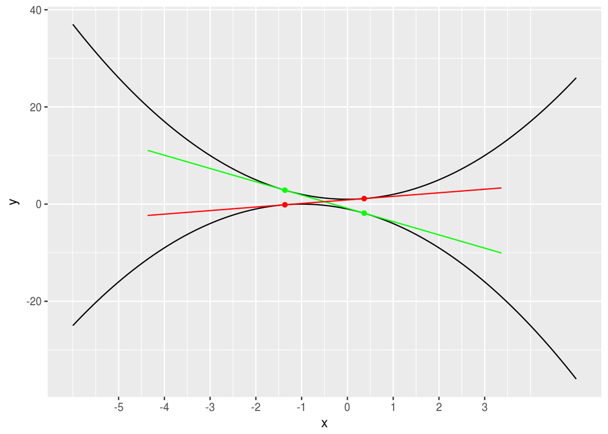

$f(x) = x^2 + x$

$g(x) = -2x^2 - 2$

$f'(x) = 2x + 1$

$g'(x) = -4x$

$m = f'(x_1) = g'(x_2)$

$m = 2x_1 +1 = -4x_2$

$x_2 = \frac{2x_1 + 1}{-4}$

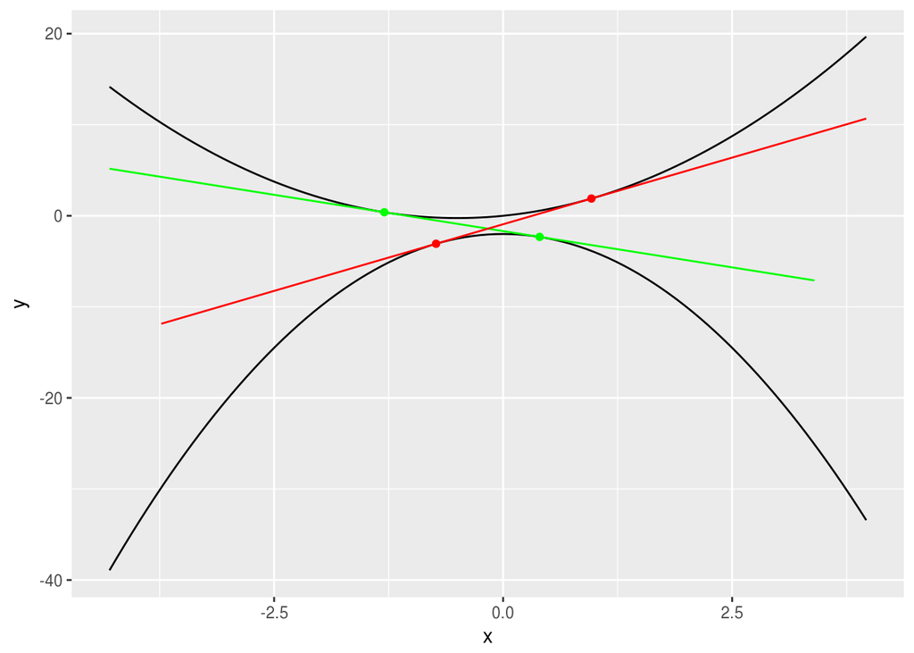

General solution for $x_1$: $\left [ \frac{1}{2 a_{0} \left(a_{0} - a_{1}\right)} \left(a_{0} \left(- b_{0} + b_{1}\right) + \sqrt{a_{0} a_{1} \left(- 4 a_{0} c_{0} + 4 a_{0} c_{1} + 4 a_{1} c_{0} - 4 a_{1} c_{1} + b_{0}^{2} - 2 b_{0} b_{1} + b_{1}^{2}\right)}\right), \quad - \frac{1}{2 a_{0} \left(a_{0} - a_{1}\right)} \left(a_{0} b_{0} - a_{0} b_{1} + \sqrt{a_{0} a_{1} \left(- 4 a_{0} c_{0} + 4 a_{0} c_{1} + 4 a_{1} c_{0} - 4 a_{1} c_{1} + b_{0}^{2} - 2 b_{0} b_{1} + b_{1}^{2}\right)}\right)\right ]$